# Vyprávíme příběh s daty

## Třetí příklad

Použijeme data o Titaniku `titanic3.xls` a uděláme histogram cen jízdenek.

```python
# Načteme data
titanic = pd.read_excel('titanic3.xls')
titanic.head()
```

|  | pclass | survived | name | sex | age | sibsp | parch | ticket | fare | cabin | embarked | boat | body | home.dest |
| --- | --- | --- | --- | --- | --- | --- | --- | --- | --- | --- | --- | --- | --- | --- |
| 0 | 1 | 1 | Allen, Miss. Elisabeth Walton | female | 29.0000 | 0 | 0 | 24160 | 211.3375 | B5 | S | 2 | NaN | St Louis, MO |
| 1 | 1 | 1 | Allison, Master. Hudson Trevor | male | 0.9167 | 1 | 2 | 113781 | 151.5500 | C22 C26 | S | 11 | NaN | Montreal, PQ / Chesterville, ON |
| 2 | 1 | 0 | Allison, Miss. Helen Loraine | female | 2.0000 | 1 | 2 | 113781 | 151.5500 | C22 C26 | S | NaN | NaN | Montreal, PQ / Chesterville, ON |
| 3 | 1 | 0 | Allison, Mr. Hudson Joshua Creighton | male | 30.0000 | 1 | 2 | 113781 | 151.5500 | C22 C26 | S | NaN | 135.0 | Montreal, PQ / Chesterville, ON |
| 4 | 1 | 0 | Allison, Mrs. Hudson J C (Bessie Waldo Daniels) | female | 25.0000 | 1 | 2 | 113781 | 151.5500 | C22 C26 | S | NaN | NaN | Montreal, PQ / Chesterville, ON |

```python
# Ukážeme popisnou statistiku pro sloupec s cenou jízdenky
titanic.fare.describe()
```

```
count    1308.000000
mean       33.295479
std        51.758668
min         0.000000
25%         7.895800
50%        14.454200
75%        31.275000
max       512.329200
Name: fare, dtype: float64
```

```python
# Vytvoříme obrázek
fig, ax = plt.subplots(figsize=(10,6), dpi= 80)
```

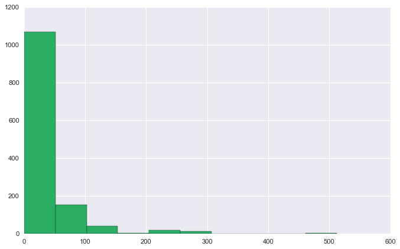

```python
# Přidáme data
fig, ax = plt.subplots(figsize=(10,6), dpi= 80)
plt.hist(titanic.fare, color='#2bae64')
plt.show()
```

Musíme odstranit chybějící hodnoty z `titanic.fare`.

```python
print(len(titanic.fare))
```

```
1309
```

```python
print(len(titanic.fare.dropna()))
```

```
1308
```

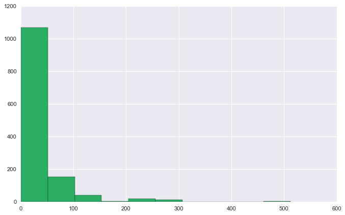

```python
# Přidáme data
fig, ax = plt.subplots(figsize=(10,6), dpi= 80)
plt.hist(titanic.fare.dropna(), color='#2bae64')
plt.show()
```

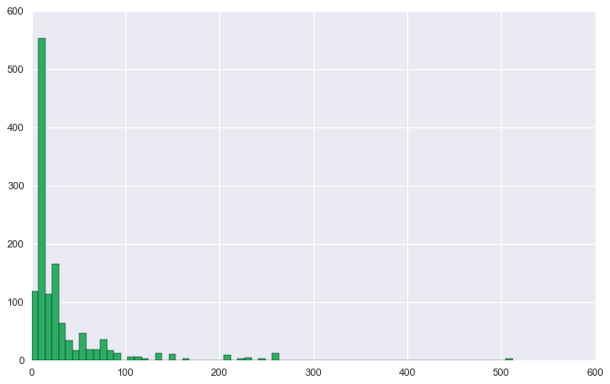

```python
# Zvětšíme počet sloupců
fig, ax = plt.subplots(figsize=(10,6), dpi= 80)
plt.hist(titanic.fare.dropna(), color='#2bae64', bins=70)
plt.show()
```

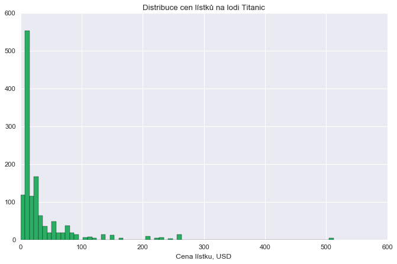

```python
# Přidáme popisky
fig, ax = plt.subplots(figsize=(10,6), dpi= 80)
plt.hist(titanic.fare.dropna(), color='#2bae64', bins=70)

ax.set(
    xlabel='Cena lístku, USD',
    title='Distribuce cen lístků na lodi Titanic'
)
plt.show()
```

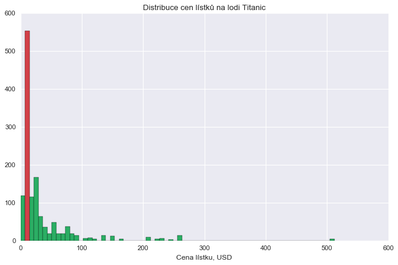

```python
# Zvýrazníme sloupec s nejčastější hodnotou
fig, ax = plt.subplots(figsize=(10,6), dpi= 80)
plt.hist(titanic.fare.dropna(), color='#2bae64', bins=70)

ax.set(
    xlabel='Cena lístku, USD',
    title='Distribuce cen lístků na lodi Titanic'
)
ax.patches[1].set_facecolor('#d24049')
plt.show()
```

Chceme u zvýrazněného sloupce ukázat o které rozmezí hodnot se jedná.

Abychom rozdělily `ticket.fare` do binů, použijeme `pd.cut` a následně spočítáme biny pomocí metody `value_counts()`

```python
# value_counts spočítá četnost hodnot ve sloupci
titanic.embarked.value_counts()
```

```
S    914
C    270
Q    123
Name: embarked, dtype: int64
```

```python
pd.cut(titanic.fare, 70).value_counts().head()
```

```
(7.319, 14.638]     553
(21.957, 29.276]    166
(-0.512, 7.319]     119
(14.638, 21.957]    115
(29.276, 36.595]     64
Name: fare, dtype: int64
```

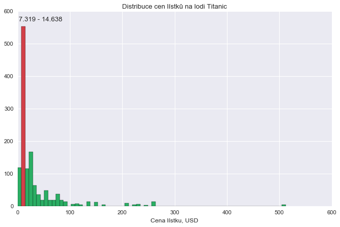

```python
# U sloupce s nejčastější hodnotou napíšeme rozmezí hodnot
fig, ax = plt.subplots(figsize=(10,6), dpi= 80)
plt.hist(titanic.fare.dropna(), color='#2bae64', bins=70)

ax.set(
    xlabel='Cena lístku, USD',
    title='Distribuce cen lístků na lodi Titanic'
)
ax.patches[1].set_facecolor('#d24049')
plt.text(2, 570, '7.319 - 14.638')
plt.show()
```

## Cvičení

Použijete data o Titaniku `titanic3.xls` a vytvořte histogram věku cestujících (`age`).

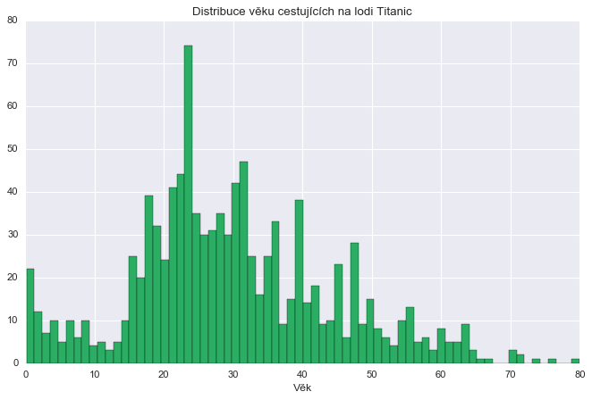

```python
fig, ax = plt.subplots(figsize=(10,6), dpi= 80)
plt.hist(titanic.age.dropna(), color='#2bae64', bins=70)

ax.set(
    xlabel='Věk',
    title='Distribuce věku cestujících na lodi Titanic'
)

plt.show()
```

## Čtvrtý příklad

Použijeme data o Titaniku `titanic3.xls` a uděláme boxplot věků cestujících (`age`) v různých třídách (`pclass`). Pro vykreslení boxplotu použíjeme [seaborn.boxplot](https://seaborn.pydata.org/generated/seaborn.boxplot.html)

```python
# Načteme data
titanic = pd.read_excel('titanic3.xls')
titanic.head()
```

|  | pclass | survived | name | sex | age | sibsp | parch | ticket | fare | cabin | embarked | boat | body | home.dest |
| --- | --- | --- | --- | --- | --- | --- | --- | --- | --- | --- | --- | --- | --- | --- |
| 0 | 1 | 1 | Allen, Miss. Elisabeth Walton | female | 29.0000 | 0 | 0 | 24160 | 211.3375 | B5 | S | 2 | NaN | St Louis, MO |
| 1 | 1 | 1 | Allison, Master. Hudson Trevor | male | 0.9167 | 1 | 2 | 113781 | 151.5500 | C22 C26 | S | 11 | NaN | Montreal, PQ / Chesterville, ON |
| 2 | 1 | 0 | Allison, Miss. Helen Loraine | female | 2.0000 | 1 | 2 | 113781 | 151.5500 | C22 C26 | S | NaN | NaN | Montreal, PQ / Chesterville, ON |
| 3 | 1 | 0 | Allison, Mr. Hudson Joshua Creighton | male | 30.0000 | 1 | 2 | 113781 | 151.5500 | C22 C26 | S | NaN | 135.0 | Montreal, PQ / Chesterville, ON |
| 4 | 1 | 0 | Allison, Mrs. Hudson J C (Bessie Waldo Daniels) | female | 25.0000 | 1 | 2 | 113781 | 151.5500 | C22 C26 | S | NaN | NaN | Montreal, PQ / Chesterville, ON |

Nejprve se podíváme na data, která chceme vykreslit.

Projdeme všechny unikátní hodnoty `pclass` a zobrazíme popisnou statistiku.

```python
 for pclass in titanic.pclass.unique():
        print('pclass ', pclass, titanic[titanic.pclass == pclass].age.describe())
```

```
pclass  1 count    284.000000
mean      39.159918
std       14.548059
min        0.916700
25%       28.000000
50%       39.000000
75%       50.000000
max       80.000000
Name: age, dtype: float64
pclass  2 count    261.000000
mean      29.506705
std       13.638628
min        0.666700
25%       22.000000
50%       29.000000
75%       36.000000
max       70.000000
Name: age, dtype: float64
pclass  3 count    501.000000
mean      24.816367
std       11.958202
min        0.166700
25%       18.000000
50%       24.000000
75%       32.000000
max       74.000000
Name: age, dtype: float64
```

```python
# Vytvoříme obrázek
fig, ax = plt.subplots(figsize=(10,6), dpi= 80)
```

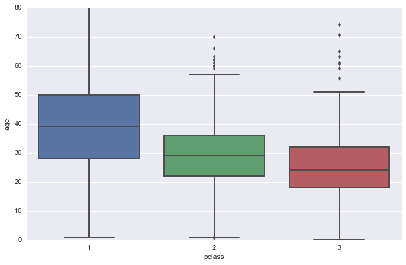

```python
# Přidáme data
fig, ax = plt.subplots(figsize=(10,6), dpi= 80)
sns.boxplot(x='pclass', y='age', data=titanic)
plt.show()
```

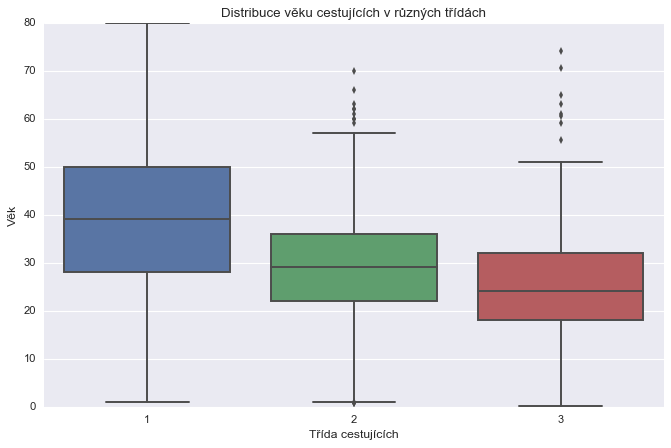

```python
# Přidáme popisky
fig, ax = plt.subplots(figsize=(10,6), dpi= 80)
sns.boxplot(x='pclass', y='age', data=titanic)

ax.set(
    xlabel='Třída cestujících',
    ylabel='Věk',
    title='Distribuce věku cestujících v různých třídách'
)
plt.show()
```

## Cvičení

Použijete data o Titaniku `titanic3.xls` a vytvořte boxplot ceny lístků (`fare`) v různých třídách (`pclass`).

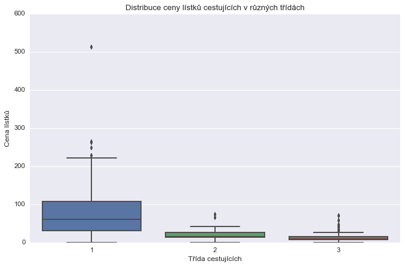

```python
fig, ax = plt.subplots(figsize=(10,6), dpi= 80)
sns.boxplot(x='pclass', y='fare', data=titanic)

ax.set(
    xlabel='Třída cestujících',
    ylabel='Cena lístků',
    title='Distribuce ceny lístků cestujících v různých třídách'
)
plt.show()
```

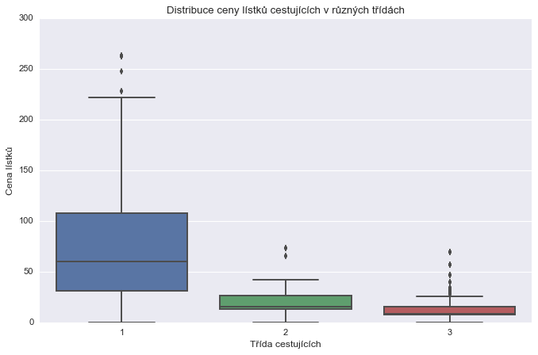

```python
# Nastavíme menší rozsah osy y, aby byly boxploty lépe vidět
fig, ax = plt.subplots(figsize=(10,6), dpi= 80)
sns.boxplot(x='pclass', y='fare', data=titanic)

ax.set(
    xlabel='Třída cestujících',
    ylabel='Cena lístků',
    title='Distribuce ceny lístků cestujících v různých třídách'
)
plt.ylim([0, 300])
plt.show()
```

```python
# Nekteří cestující neplatili za listek - u boxplotů vidíme nulové hodnoty
titanic[titanic.fare == 0]
# Jednalo se zamestnance nebo lidi, kteří dostali listek zadarmo, protože byli součástí White Star Line
```

|  | pclass | survived | name | sex | age | sibsp | parch | ticket | fare | cabin | embarked | boat | body | home.dest |
| --- | --- | --- | --- | --- | --- | --- | --- | --- | --- | --- | --- | --- | --- | --- |
| 7 | 1 | 0 | Andrews, Mr. Thomas Jr | male | 39.0 | 0 | 0 | 112050 | 0.0 | A36 | S | NaN | NaN | Belfast, NI |
| 70 | 1 | 0 | Chisholm, Mr. Roderick Robert Crispin | male | NaN | 0 | 0 | 112051 | 0.0 | NaN | S | NaN | NaN | Liverpool, England / Belfast |
| 125 | 1 | 0 | Fry, Mr. Richard | male | NaN | 0 | 0 | 112058 | 0.0 | B102 | S | NaN | NaN | NaN |
| 150 | 1 | 0 | Harrison, Mr. William | male | 40.0 | 0 | 0 | 112059 | 0.0 | B94 | S | NaN | 110.0 | NaN |
| 170 | 1 | 1 | Ismay, Mr. Joseph Bruce | male | 49.0 | 0 | 0 | 112058 | 0.0 | B52 B54 B56 | S | C | NaN | Liverpool |
| 223 | 1 | 0 | Parr, Mr. William Henry Marsh | male | NaN | 0 | 0 | 112052 | 0.0 | NaN | S | NaN | NaN | Belfast |
| 234 | 1 | 0 | Reuchlin, Jonkheer. John George | male | 38.0 | 0 | 0 | 19972 | 0.0 | NaN | S | NaN | NaN | Rotterdam, Netherlands |
| 363 | 2 | 0 | Campbell, Mr. William | male | NaN | 0 | 0 | 239853 | 0.0 | NaN | S | NaN | NaN | Belfast |
| 384 | 2 | 0 | Cunningham, Mr. Alfred Fleming | male | NaN | 0 | 0 | 239853 | 0.0 | NaN | S | NaN | NaN | Belfast |
| 410 | 2 | 0 | Frost, Mr. Anthony Wood "Archie" | male | NaN | 0 | 0 | 239854 | 0.0 | NaN | S | NaN | NaN | Belfast |
| 473 | 2 | 0 | Knight, Mr. Robert J | male | NaN | 0 | 0 | 239855 | 0.0 | NaN | S | NaN | NaN | Belfast |
| 528 | 2 | 0 | Parkes, Mr. Francis "Frank" | male | NaN | 0 | 0 | 239853 | 0.0 | NaN | S | NaN | NaN | Belfast |
| 581 | 2 | 0 | Watson, Mr. Ennis Hastings | male | NaN | 0 | 0 | 239856 | 0.0 | NaN | S | NaN | NaN | Belfast |
| 896 | 3 | 0 | Johnson, Mr. Alfred | male | 49.0 | 0 | 0 | LINE | 0.0 | NaN | S | NaN | NaN | NaN |
| 898 | 3 | 0 | Johnson, Mr. William Cahoone Jr | male | 19.0 | 0 | 0 | LINE | 0.0 | NaN | S | NaN | NaN | NaN |
| 963 | 3 | 0 | Leonard, Mr. Lionel | male | 36.0 | 0 | 0 | LINE | 0.0 | NaN | S | NaN | NaN | NaN |
| 1254 | 3 | 1 | Tornquist, Mr. William Henry | male | 25.0 | 0 | 0 | LINE | 0.0 | NaN | S | 15 | NaN | NaN |

## Navíc: analýza počtu telefonů

```python
# Načteme data
data = pd.read_csv(
    'http://vincentarelbundock.github.io/Rdatasets/csv/datasets/WorldPhones.csv',
#     index_col=0
)
#Přejmenujeme sloupce
data.rename(columns={'Unnamed: 0':'Year'}, inplace=True)
data
```

|  | Year | N.Amer | Europe | Asia | S.Amer | Oceania | Africa | Mid.Amer |
| --- | --- | --- | --- | --- | --- | --- | --- | --- |
| 0 | 1951 | 45939 | 21574 | 2876 | 1815 | 1646 | 89 | 555 |
| 1 | 1956 | 60423 | 29990 | 4708 | 2568 | 2366 | 1411 | 733 |
| 2 | 1957 | 64721 | 32510 | 5230 | 2695 | 2526 | 1546 | 773 |
| 3 | 1958 | 68484 | 35218 | 6662 | 2845 | 2691 | 1663 | 836 |
| 4 | 1959 | 71799 | 37598 | 6856 | 3000 | 2868 | 1769 | 911 |
| 5 | 1960 | 76036 | 40341 | 8220 | 3145 | 3054 | 1905 | 1008 |
| 6 | 1961 | 79831 | 43173 | 9053 | 3338 | 3224 | 2005 | 1076 |

```python
# Můžeme proiterovat všemi sloupcí kromě Year abychom vytvořili graf
data.columns[1:]
```

```
Index(['N.Amer', 'Europe', 'Asia', 'S.Amer', 'Oceania', 'Africa', 'Mid.Amer'], dtype='object')
```

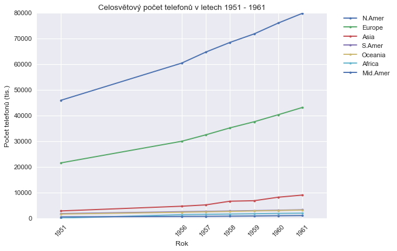

```python
fig, ax = plt.subplots()
for column in data.columns[1:]:
    # Pro každy region se vykreslí křívka do stejného grafu
    plt.plot(data.Year, data[column], marker='.', label=column)
    plt.ylim(0, 80000)
# Nastavíme, aby se správně zobrazovaly roky
plt.xticks(data.Year, data.Year.astype(str), rotation=45)
ax.set(
    xlabel='Rok', ylabel='Počet telefonů (tis.)',
    title='Celosvětový počet telefonů v letech {} - {}'.format(data.Year.min(), data.Year.max())
)
plt.legend(bbox_to_anchor=(1.05, 1), loc=2, borderaxespad=0.)
plt.show()
```